# finalAIP2

```python
from google.colab import drive
drive.mount('/content/drive')
```

```python
! cp "/content/drive/MyDrive/dataset.zip" .
```

```python
!unzip dataset.zip -d /content/desPhase2
```

[output not shown]

[output cut: 2748 more lines]

[output not shown]

فاز اول: بررسی و پیش پردازش داده

با استفاده از $Keras$ داده ها را بخوانید. سپس تصاویر را $grayscale$ کنید.

تعداد داده های خوانده شده و تعداد کلاس های موجود را چاپ کنید.

```python
from tensorflow.keras import *
dataGenerator = preprocessing.image.ImageDataGenerator(rescale = 1/255.0, validation_split = 0)
trainData = dataGenerator.flow_from_directory( 'desPhase2/dataset/train', batch_size=32, target_size=(100, 100), class_mode = 'categorical', color_mode = 'grayscale', subset = "training", shuffle = True)
```

```
Found 1945 images belonging to 4 classes.
```

تعداد تصاویر هر کلاس را محاسبه کنید و برای آن نمودار میله ای رسم کنید.

```python
from collections import Counter

counter = Counter(trainData.classes)

print(counter.items())
```

```
dict_items([(0, 521), (1, 462), (2, 507), (3, 455)])
```

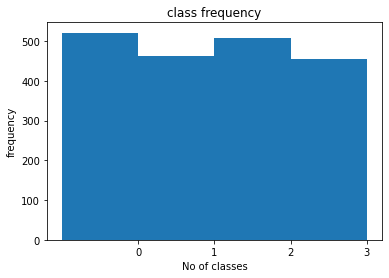

```python
import matplotlib.pyplot as plt
import numpy as np
labels, values = zip(*counter.items())

indexes = np.arange(len(labels))
width = 1

plt.title('class frequency')
plt.xlabel('No of classes')
plt.ylabel('frequency')
plt.bar(indexes, values, width)
plt.xticks(indexes + width * 0.5, labels)
plt.show()
```

از هر کلاس موجود فقط یک تصویر همراه با نام کلاس آن را نشان دهید

```
raven
```

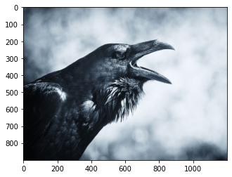

```python
import os, random
import matplotlib.image as mpimg
print("raven")
random_raven = random.choice(os.listdir("/content/desPhase2/dataset/train/raven/"))
img = mpimg.imread("/content/desPhase2/dataset/train/raven/" + random_raven)
imgplot = plt.imshow(img)
```

```
racoon
```

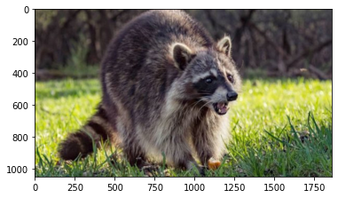

```python
print("racoon")
random_racoon = random.choice(os.listdir("/content/desPhase2/dataset/train/racoon/"))
img = mpimg.imread("/content/desPhase2/dataset/train/racoon/" + random_racoon)
imgplot = plt.imshow(img)
```

```
elk
```

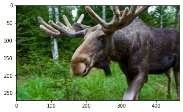

```python
print("elk")
random_elk = random.choice(os.listdir("/content/desPhase2/dataset/train/elk/"))
img = mpimg.imread("/content/desPhase2/dataset/train/elk/" + random_elk)
imgplot = plt.imshow(img)
```

```
bald_eagle
```

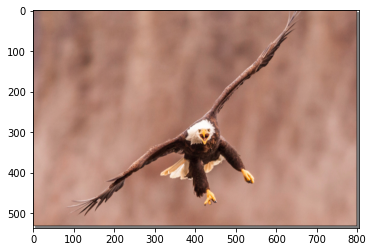

```python
print("bald_eagle")
random_bald_eagle = random.choice(os.listdir("/content/desPhase2/dataset/train/bald_eagle/"))
img = mpimg.imread("/content/desPhase2/dataset/train/bald_eagle/" + random_bald_eagle)
imgplot = plt.imshow(img)
```

بخش $train$ دیتاست را به دو بخش $train$ و $validation$ و با مقیاس مناسب تقسیم کنید

```python
dataGenerator = preprocessing.image.ImageDataGenerator(rescale = 1/255.0, validation_split = 0.3)
trainData = dataGenerator.flow_from_directory( 'desPhase2/dataset/train', batch_size=32, target_size=(100, 100), class_mode = 'categorical', color_mode = 'grayscale', subset = "training", shuffle = True)
validationData = dataGenerator.flow_from_directory( 'desPhase2/dataset/train', batch_size=32, target_size=(100, 100), class_mode = 'categorical', color_mode = 'grayscale', subset = "validation", shuffle = True)
```

```
Found 1363 images belonging to 4 classes.
Found 582 images belonging to 4 classes.
```

برای برچسب ها $one hot encoding$ انجام دهید و دلیل این کار را شرح دهید

```python
from tensorflow.keras.utils import to_categorical
one_hot_encode = to_categorical(trainData.labels)
print(one_hot_encode)
```

```
[[1. 0. 0. 0.]
 [1. 0. 0. 0.]
 [1. 0. 0. 0.]
 ...
 [0. 0. 0. 1.]
 [0. 0. 0. 1.]
 [0. 0. 0. 1.]]
```

فاز دوم: طراحی شبکه عصبی

```python
import tensorflow as tf
from keras.layers import Dense, Input, Flatten
input = tf.keras.Input(shape = (100, 100, 1))

output = tf.keras.layers.Flatten()(input)
output = tf.keras.layers.Dense(1024, activation = "relu")(output)
output = tf.keras.layers.Dense(512, activation = "relu")(output)
output = tf.keras.layers.Dense(4, activation = "softmax")(output)
```

```python
model = models.Model(inputs = input, outputs = output)
```

```python
model.compile( optimizer = tf.keras.optimizers.SGD(learning_rate = 0.01), loss = 'categorical_crossentropy', metrics=['accuracy'])
```

```python
history = model.fit(trainData, validation_data = validationData, epochs = 10)
```

accuracy plot:

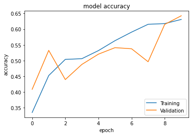

```python
plt.plot(history.history['accuracy'], label='Training')
plt.plot(history.history['val_accuracy'], label='Validation')
plt.legend(loc='lower right')
plt.title('model accuracy')
plt.ylabel('accuracy')
plt.xlabel('epoch')
plt.show()
```

loss plot:

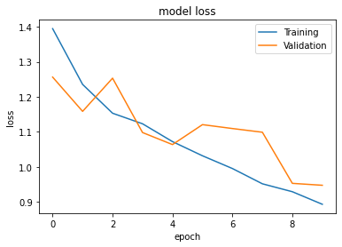

```python
plt.plot(history.history['loss'], label='Training')
plt.plot(history.history['val_loss'], label='Validation')
plt.legend(loc='upper right')
plt.title('model loss')
plt.ylabel('loss')
plt.xlabel('epoch')
plt.show()
```

```python
trainPrime = dataGenerator.flow_from_directory( 'desPhase2/dataset/train', batch_size=1363, target_size=(100, 100), class_mode = 'categorical', color_mode = 'grayscale', subset = "training", shuffle = True)
validationPrime = dataGenerator.flow_from_directory( 'desPhase2/dataset/train', batch_size=582, target_size=(100, 100), class_mode = 'categorical', color_mode = 'grayscale', subset = "validation", shuffle = True)
```

```
Found 1363 images belonging to 4 classes.
Found 582 images belonging to 4 classes.
```

```python
from sklearn.metrics import classification_report
yPredTrain = model.predict(trainPrime)
predictedCategoriesTrain = np.argmax(yPredTrain, axis = 1)
X, y = trainPrime.next()
trueCategoriesArgmaxTrain = np.argmax(y, axis = 1)
classLables = ["0", "1", "2", "3"]
print(classification_report(trueCategoriesArgmaxTrain, predictedCategoriesTrain, target_names = classLables))
```

```
              precision    recall  f1-score   support

           0       0.31      0.26      0.28       365
           1       0.22      0.31      0.26       324
           2       0.30      0.26      0.28       355
           3       0.23      0.22      0.22       319

    accuracy                           0.26      1363
   macro avg       0.27      0.26      0.26      1363
weighted avg       0.27      0.26      0.26      1363
```

```python
yPredValidation = model.predict(validationPrime)
predictedCategoriesTest = np.argmax(yPredValidation , axis = 1)
X, y = validationPrime.next()
trueCategoriesArgmaxTest = np.argmax(y, axis = 1)
classLables = ["0", "1", "2", "3"]
print(classification_report(trueCategoriesArgmaxTest, predictedCategoriesTest, target_names = classLables))
```

```
              precision    recall  f1-score   support

           0       0.21      0.19      0.20       156
           1       0.28      0.38      0.32       138
           2       0.30      0.24      0.27       152
           3       0.24      0.22      0.23       136

    accuracy                           0.26       582
   macro avg       0.26      0.26      0.26       582
weighted avg       0.26      0.26      0.25       582
```

```python
model.summary()
```

```
Model: "model_1"
_________________________________________________________________
 Layer (type)                Output Shape              Param #
=================================================================
 input_1 (InputLayer)        [(None, 100, 100, 1)]     0

 flatten (Flatten)           (None, 10000)             0

 dense (Dense)               (None, 1024)              10241024

 dense_1 (Dense)             (None, 512)               524800

 dense_2 (Dense)             (None, 4)                 2052

=================================================================
Total params: 10,767,876
Trainable params: 10,767,876
Non-trainable params: 0
_________________________________________________________________
```

param = (input date dim + 1) * No. of neurons

dense => No. of neurons = 1024, param = (10000+1) * 1024 = 10241024

dense_1 => No. of neurons = 512, param = (1024+1) * 512 = 524800

dense_2 => No. of neurons = 4, param = ( 512+1) * 4 = 2052

فاز سوم: طبقه بندی داده ها

قسمت اول)

تحقیق کنید که $momentum$ چیست و چرا استفاده از آن مفید است؟

روشی است که به تسریع بردارهای شیب در جهت مناسب کمک میکند و منحر به همگرایی سریع تر میشود. همچنین باعث میشود تا در مینیمم های محلی گیر نیافتد.

Training with momentum 0.5:

```python
input = tf.keras.Input(shape = (100, 100, 1))

output = tf.keras.layers.Flatten()(input)
output = tf.keras.layers.Dense(1024, activation = "relu")(output)
output = tf.keras.layers.Dense(1024, activation = "relu")(output)
output = tf.keras.layers.Dense(512, activation = "relu")(output)
output = tf.keras.layers.Dense(4, activation = "softmax")(output)

momentumModel = models.Model(inputs = input, outputs = output)
momentumModel.compile( optimizer = tf.keras.optimizers.SGD(learning_rate = 0.01, momentum=0.5), loss = 'categorical_crossentropy', metrics=['accuracy'])
history = momentumModel.fit(trainData, validation_data = validationData, epochs = 10)
```

accuracy plot

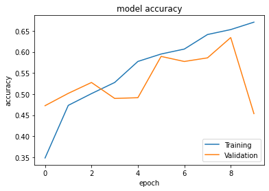

```python
plt.plot(history.history['accuracy'], label='Training')
plt.plot(history.history['val_accuracy'], label='Validation')
plt.legend(loc='lower right')
plt.title('model accuracy')
plt.ylabel('accuracy')
plt.xlabel('epoch')
plt.show()
```

loss plot

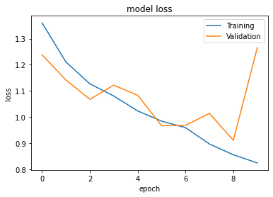

```python
plt.plot(history.history['loss'], label='Training')
plt.plot(history.history['val_loss'], label='Validation')
plt.legend(loc='upper right')
plt.title('model loss')
plt.ylabel('loss')
plt.xlabel('epoch')
plt.show()
```

```python
yPredTrain = momentumModel.predict(trainPrime)
predictedCategoriesTrain = np.argmax(yPredTrain, axis = 1)
X, y = trainPrime.next()
trueCategoriesArgmaxTrain = np.argmax(y, axis = 1)
classLables = ["0", "1", "2", "3"]
print(classification_report(trueCategoriesArgmaxTrain, predictedCategoriesTrain, target_names = classLables))
```

```
              precision    recall  f1-score   support

           0       0.28      0.12      0.17       365
           1       0.23      0.18      0.20       324
           2       0.31      0.06      0.10       355
           3       0.25      0.68      0.36       319

    accuracy                           0.25      1363
   macro avg       0.27      0.26      0.21      1363
weighted avg       0.27      0.25      0.20      1363
```

```python
yPredValidation = momentumModel.predict(validationPrime)
predictedCategoriesTest = np.argmax(yPredValidation , axis = 1)
X, y = validationPrime.next()
trueCategoriesArgmaxTest = np.argmax(y, axis = 1)
classLables = ["0", "1", "2", "3"]
print(classification_report(trueCategoriesArgmaxTest, predictedCategoriesTest, target_names = classLables))
```

```
              precision    recall  f1-score   support

           0       0.32      0.15      0.20       156
           1       0.24      0.20      0.22       138
           2       0.22      0.04      0.07       152
           3       0.23      0.62      0.33       136

    accuracy                           0.24       582
   macro avg       0.25      0.25      0.20       582
weighted avg       0.25      0.24      0.20       582
```

Training with momentum 0.9:

```python
input = tf.keras.Input(shape = (100, 100, 1))

output = tf.keras.layers.Flatten()(input)
output = tf.keras.layers.Dense(1024, activation = "relu")(output)
output = tf.keras.layers.Dense(1024, activation = "relu")(output)
output = tf.keras.layers.Dense(512, activation = "relu")(output)
output = tf.keras.layers.Dense(4, activation = "softmax")(output)

momentumModel2 = models.Model(inputs = input, outputs = output)
momentumModel2.compile( optimizer = tf.keras.optimizers.SGD(learning_rate = 0.01, momentum=0.9), loss = 'categorical_crossentropy', metrics=['accuracy'])
history = momentumModel2.fit(trainData, validation_data = validationData, epochs = 10)
```

accuracy plot:

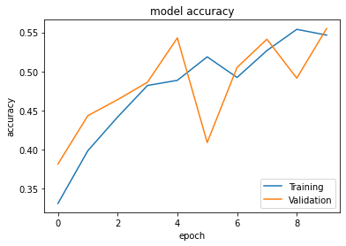

```python
plt.plot(history.history['accuracy'], label='Training')
plt.plot(history.history['val_accuracy'], label='Validation')
plt.legend(loc='lower right')
plt.title('model accuracy')
plt.ylabel('accuracy')
plt.xlabel('epoch')
plt.show()
```

loss plot:

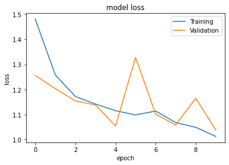

```python
plt.plot(history.history['loss'], label='Training')
plt.plot(history.history['val_loss'], label='Validation')
plt.legend(loc='upper right')
plt.title('model loss')
plt.ylabel('loss')
plt.xlabel('epoch')
plt.show()
```

```python
yPredTrain = momentumModel2.predict(trainPrime)
predictedCategoriesTrain = np.argmax(yPredTrain, axis = 1)
X, y = trainPrime.next()
trueCategoriesArgmaxTrain = np.argmax(y, axis = 1)
classLables = ["0", "1", "2", "3"]
print(classification_report(trueCategoriesArgmaxTrain, predictedCategoriesTrain, target_names = classLables))
```

```
              precision    recall  f1-score   support

           0       0.27      0.37      0.31       365
           1       0.25      0.16      0.20       324
           2       0.26      0.25      0.26       355
           3       0.24      0.24      0.24       319

    accuracy                           0.26      1363
   macro avg       0.26      0.26      0.25      1363
weighted avg       0.26      0.26      0.25      1363
```

```python
yPredValidation = momentumModel2.predict(validationPrime)
predictedCategoriesTest = np.argmax(yPredValidation , axis = 1)
X, y = validationPrime.next()
trueCategoriesArgmaxTest = np.argmax(y, axis = 1)
classLables = ["0", "1", "2", "3"]
print(classification_report(trueCategoriesArgmaxTest, predictedCategoriesTest, target_names = classLables))
```

```
              precision    recall  f1-score   support

           0       0.28      0.40      0.33       156
           1       0.23      0.14      0.18       138
           2       0.25      0.24      0.24       152
           3       0.29      0.27      0.28       136

    accuracy                           0.27       582
   macro avg       0.26      0.26      0.26       582
weighted avg       0.26      0.27      0.26       582
```

ایا همواره با افزایش $momentum$ نتیجه بهبود میابد؟

خیر. در واقع آپدیت وزن ها زیاد میشود و نوسان زیادی را شاهد خواهیم بود.

```python
input = tf.keras.Input(shape = (100, 100, 1))

output = tf.keras.layers.Flatten()(input)
output = tf.keras.layers.Dense(1024, activation = "relu")(output)
output = tf.keras.layers.Dense(1024, activation = "relu")(output)
output = tf.keras.layers.Dense(512, activation = "relu")(output)
output = tf.keras.layers.Dense(4, activation = "softmax")(output)

adamModel = models.Model(inputs = input, outputs = output)
adamModel.compile( optimizer = tf.keras.optimizers.Adam(learning_rate=0.001), loss = 'categorical_crossentropy', metrics=['accuracy'])
history = adamModel.fit(trainData, validation_data = validationData, epochs = 10)
```

accuracy plot:

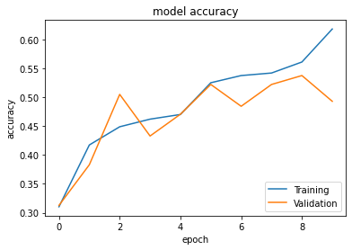

```python
plt.plot(history.history['accuracy'], label='Training')
plt.plot(history.history['val_accuracy'], label='Validation')
plt.legend(loc='lower right')
plt.title('model accuracy')
plt.ylabel('accuracy')
plt.xlabel('epoch')
plt.show()
```

loss plot:

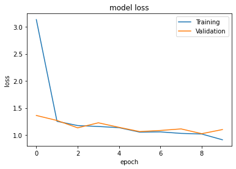

```python
plt.plot(history.history['loss'], label='Training')
plt.plot(history.history['val_loss'], label='Validation')
plt.legend(loc='upper right')
plt.title('model loss')
plt.ylabel('loss')
plt.xlabel('epoch')
plt.show()
```

```python
yPredTrain = adamModel.predict(trainPrime)
predictedCategoriesTrain = np.argmax(yPredTrain, axis = 1)
X, y = trainPrime.next()
trueCategoriesArgmaxTrain = np.argmax(y, axis = 1)
classLables = ["0", "1", "2", "3"]
print(classification_report(trueCategoriesArgmaxTrain, predictedCategoriesTrain, target_names = classLables))
```

```
              precision    recall  f1-score   support

           0       0.23      0.10      0.14       365
           1       0.26      0.08      0.13       324
           2       0.24      0.36      0.29       355
           3       0.24      0.41      0.30       319

    accuracy                           0.24      1363
   macro avg       0.24      0.24      0.21      1363
weighted avg       0.24      0.24      0.21      1363
```

```python
yPredValidation = adamModel.predict(validationPrime)
predictedCategoriesTest = np.argmax(yPredValidation , axis = 1)
X, y = validationPrime.next()
trueCategoriesArgmaxTest = np.argmax(y, axis = 1)
classLables = ["0", "1", "2", "3"]
print(classification_report(trueCategoriesArgmaxTest, predictedCategoriesTest, target_names = classLables))
```

```
              precision    recall  f1-score   support

           0       0.25      0.14      0.18       156
           1       0.31      0.08      0.13       138
           2       0.26      0.39      0.31       152
           3       0.25      0.43      0.32       136

    accuracy                           0.26       582
   macro avg       0.27      0.26      0.23       582
weighted avg       0.27      0.26      0.23       582
```

سرعت $adam$ بهتره اما دقت $SDG$ بیشتر است

قسمت دوم)

```python
history = adamModel.fit(trainData, validation_data = validationData, epochs = 20)
```

accuracy plot:

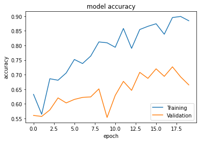

```python
plt.plot(history.history['accuracy'], label='Training')
plt.plot(history.history['val_accuracy'], label='Validation')
plt.legend(loc='lower right')
plt.title('model accuracy')
plt.ylabel('accuracy')
plt.xlabel('epoch')
plt.show()
```

loss plot:

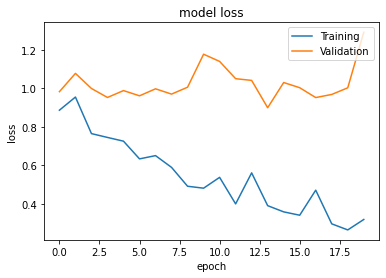

```python
plt.plot(history.history['loss'], label='Training')
plt.plot(history.history['val_loss'], label='Validation')
plt.legend(loc='upper right')
plt.title('model loss')
plt.ylabel('loss')
plt.xlabel('epoch')
plt.show()
```

```python
yPredTrain = adamModel.predict(trainPrime)
predictedCategoriesTrain = np.argmax(yPredTrain, axis = 1)
X, y = trainPrime.next()
trueCategoriesArgmaxTrain = np.argmax(y, axis = 1)
classLables = ["0", "1", "2", "3"]
print(classification_report(trueCategoriesArgmaxTrain, predictedCategoriesTrain, target_names = classLables))
```

```
              precision    recall  f1-score   support

           0       0.24      0.23      0.24       365
           1       0.25      0.34      0.29       324
           2       0.26      0.21      0.23       355
           3       0.23      0.22      0.23       319

    accuracy                           0.25      1363
   macro avg       0.25      0.25      0.25      1363
weighted avg       0.25      0.25      0.25      1363
```

```python
yPredValidation = adamModel.predict(validationPrime)
predictedCategoriesTest = np.argmax(yPredValidation , axis = 1)
X, y = validationPrime.next()
trueCategoriesArgmaxTest = np.argmax(y, axis = 1)
classLables = ["0", "1", "2", "3"]
print(classification_report(trueCategoriesArgmaxTest, predictedCategoriesTest, target_names = classLables))
```

[output not shown]

با توجه به خروجی مدل با 20 ایپاک بهتر از 10 ایپاک شده است

از $gradient descent$ استفاده میکنیم که $iterative$ است و با افزایش ایپاک ها وزن ها تغییر میکنند و به مدل بهنیه نزدیک میشوند.

بستگی به سایر و نوع داده دارد. باید مراقب بود که $overfitting$ رخ ندهد امابرای اینکه یادگیری درست انجام شود معمولا نیاز از که در چند ایپاک انجام شود.

```python
history = adamModel.fit(trainData, validation_data = validationData, epochs = 40)
```

accuracy plot:

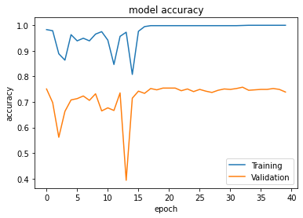

```python
plt.plot(history.history['accuracy'], label='Training')
plt.plot(history.history['val_accuracy'], label='Validation')
plt.legend(loc='lower right')
plt.title('model accuracy')
plt.ylabel('accuracy')
plt.xlabel('epoch')
plt.show()
```

loss plot:

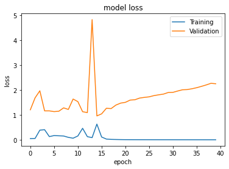

```python
plt.plot(history.history['loss'], label='Training')
plt.plot(history.history['val_loss'], label='Validation')
plt.legend(loc='upper right')
plt.title('model loss')
plt.ylabel('loss')
plt.xlabel('epoch')
plt.show()
```

همانطور که مشاهده میشود بعد از صفر شدن $loss$ برای ترین ، $loss$ برای $validation$ شروع به افزایش است

خیر. از راه های مقابله آن: یک پیچیدگی مدل مان را کم کنیم، دو $earlystopping$ بعد از اتمام یادگیری باید توقف کنیم

قسمت سوم)

```python
input = tf.keras.Input(shape = (100, 100, 1))

output = tf.keras.layers.Flatten()(input)
output = tf.keras.layers.Dense(1024, activation = "relu")(output)
output = tf.keras.layers.Dense(1024, activation = "relu")(output)
output = tf.keras.layers.Dense(512, activation = "relu")(output)
output = tf.keras.layers.Dense(4, activation = "softmax")(output)

adamMSEModel = models.Model(inputs = input, outputs = output)
adamMSEModel.compile( optimizer = tf.keras.optimizers.Adam(learning_rate=0.001), loss='mean_squared_error', metrics=['accuracy'])
history = adamMSEModel.fit(trainData, validation_data = validationData, epochs = 20)
```

accuracy plot:

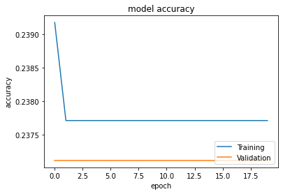

```python
plt.plot(history.history['accuracy'], label='Training')
plt.plot(history.history['val_accuracy'], label='Validation')
plt.legend(loc='lower right')
plt.title('model accuracy')
plt.ylabel('accuracy')
plt.xlabel('epoch')
plt.show()
```

loss plot:

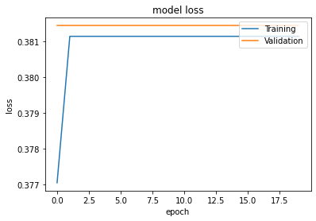

```python
plt.plot(history.history['loss'], label='Training')
plt.plot(history.history['val_loss'], label='Validation')
plt.legend(loc='upper right')
plt.title('model loss')
plt.ylabel('loss')
plt.xlabel('epoch')
plt.show()
```

```python
yPredTrain = adamMSEModel.predict(trainPrime)
predictedCategoriesTrain = np.argmax(yPredTrain, axis = 1)
X, y = trainPrime.next()
trueCategoriesArgmaxTrain = np.argmax(y, axis = 1)
classLables = ["0", "1", "2", "3"]
print(classification_report(trueCategoriesArgmaxTrain, predictedCategoriesTrain, target_names = classLables))
```

```
              precision    recall  f1-score   support

           0       0.00      0.00      0.00       365
           1       0.24      1.00      0.38       324
           2       0.00      0.00      0.00       355
           3       0.00      0.00      0.00       319

    accuracy                           0.24      1363
   macro avg       0.06      0.25      0.10      1363
weighted avg       0.06      0.24      0.09      1363
```

```python
yPredValidation = adamModel.predict(validationPrime)
predictedCategoriesTest = np.argmax(yPredValidation , axis = 1)
X, y = validationPrime.next()
trueCategoriesArgmaxTest = np.argmax(y, axis = 1)
classLables = ["0", "1", "2", "3"]
print(classification_report(trueCategoriesArgmaxTest, predictedCategoriesTest, target_names = classLables))
```

```
              precision    recall  f1-score   support

           0       0.29      0.30      0.29       156
           1       0.24      0.24      0.24       138
           2       0.30      0.26      0.28       152
           3       0.22      0.24      0.23       136

    accuracy                           0.26       582
   macro avg       0.26      0.26      0.26       582
weighted avg       0.26      0.26      0.26       582
```

در واقع $categorical cross entropy$ برای $classification$ بهتر از $MSE$ است

در واقع در $mse$ فرض بر این است که داده ها از توزیع نرمال تولید شده اند و در حالی است که مثلا مسئله دسته بندی به دو کلاس توزیع نرمال نیست و توزیع برنولی است.

برای $regresson$ مناسب است

قسمت چهارم)

```python
import tensorflow as tf
from tensorflow.keras import *
from keras.layers import Dense, Input, Flatten


input = tf.keras.Input(shape = (100, 100, 1))

output = tf.keras.layers.Flatten()(input)
output = tf.keras.layers.Dense(1024, activation = "relu", kernel_regularizer = tf.keras.regularizers.l2(0.0001))(output)
output = tf.keras.layers.Dense(1024, activation = "relu", kernel_regularizer = tf.keras.regularizers.l2(0.0001))(output)
output = tf.keras.layers.Dense(512, activation = "relu", kernel_regularizer = tf.keras.regularizers.l2(0.0001))(output)
output = tf.keras.layers.Dense(4, activation = "softmax", kernel_regularizer = tf.keras.regularizers.l2(0.0001))(output)

adamREModel = models.Model(inputs = input, outputs = output)
adamREModel.compile( optimizer = tf.keras.optimizers.Adam(learning_rate=0.001), loss='mean_squared_error', metrics=['accuracy'])
history = adamREModel.fit(trainData, validation_data = validationData, epochs = 20)
```

accuracy plot:

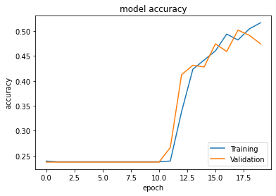

```python
import matplotlib.pyplot as plt
plt.plot(history.history['accuracy'], label='Training')
plt.plot(history.history['val_accuracy'], label='Validation')
plt.legend(loc='lower right')
plt.title('model accuracy')
plt.ylabel('accuracy')
plt.xlabel('epoch')
plt.show()
```

loss plot:

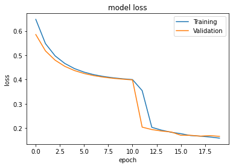

```python
plt.plot(history.history['loss'], label='Training')
plt.plot(history.history['val_loss'], label='Validation')
plt.legend(loc='upper right')
plt.title('model loss')
plt.ylabel('loss')
plt.xlabel('epoch')
plt.show()
```

```python
import numpy as np
from sklearn.metrics import classification_report
yPredTrain = adamREModel.predict(trainPrime)
predictedCategoriesTrain = np.argmax(yPredTrain, axis = 1)
X, y = trainPrime.next()
trueCategoriesArgmaxTrain = np.argmax(y, axis = 1)
classLables = ["0", "1", "2", "3"]
print(classification_report(trueCategoriesArgmaxTrain, predictedCategoriesTrain, target_names = classLables))
```

```
              precision    recall  f1-score   support

           0       0.25      0.23      0.24       365
           1       0.22      0.28      0.25       324
           2       0.25      0.06      0.10       355
           3       0.25      0.41      0.31       319

    accuracy                           0.24      1363
   macro avg       0.24      0.25      0.22      1363
weighted avg       0.24      0.24      0.22      1363
```